# AIML-505: Large Language Models and Generative Artificial Intelligence

## Workshop 3: AI Leadership, Storytelling, and Retrieval-Augmented Generation

### Indiana Wesleyan University

#### Dr. Eskinder Belete Summer 2026

1. Introduction
   - Workshop Overview and Learning Objectives
2. Key Terminologies for Workshop 3
   - Multidisciplinary AI Teams
   - Cross-Functional Collaboration
   - AI Storytelling
   - Tool Chaining
   - AI Workflow
   - Knowledge Base
   - Retrieval-Augmented Generation
   - Retriever
   - Embeddings and Vector Search
   - Grounded Generation
   - Visual Summary: Enterprise RAG Workflow
3. Interactive Demonstrations
   - Setting Up the Python Environment
   - Importing Required Libraries
   - Exploring the Microsoft Enterprise Knowledge Repository
   - Mapping Cross-Functional AI Stakeholders
   - Designing an AI Storytelling Workflow
   - Demonstrating a Chained AI Workflow
   - Understanding the RAG Pipeline
   - Simulating Document Retrieval
   - Evaluating RAG Responses
4. Enterprise Case Studies
   - Microsoft Knowledge Management
   - Food and Beverage RAG Use Case
   - Customer Service and Product Information
   - Data Privacy, Security, and Governance
   - Executive Leadership Perspectives
5. Summary
6. References, Further Reading, and Data Sources

# 1. Introduction

## Workshop Overview and Learning Objectives

Building on the foundational concepts introduced in Workshops 1 and 2, Workshop 3 shifts attention from understanding and evaluating Generative AI to **leading integrated AI initiatives across organizational functions**. Students will examine how leaders align technical and non-technical contributors, translate AI capabilities into business language, resolve cross-functional tensions, and guide teams toward shared outcomes. This leadership perspective reflects the principle of hybrid intelligence, in which human judgment, contextual awareness, ethical reasoning, and creativity complement the computational capabilities of artificial intelligence rather than being displaced by them (Dellermann et al., 2019).

A second emphasis of this workshop is the strategic use of Generative AI for product storytelling, brand communication, and organizational innovation. Effective storytelling enables leaders to connect technical capabilities with customer needs, organizational values, and strategic objectives. AI tools can assist with audience analysis, content generation, visual development, personalization, and rapid iteration; however, human oversight remains necessary to preserve factual accuracy, originality, cultural sensitivity, transparency, and brand integrity. Students will therefore consider storytelling not merely as a marketing technique, but as a leadership practice for communicating value, building stakeholder understanding, and guiding responsible adoption.

The workshop also introduces **AI tool chaining**, in which the output of one system becomes the input to another. A multi-tool workflow may combine data retrieval, language generation, image or video production, and human validation to address a complex business problem. Such workflows illustrate an important feature of contemporary enterprise AI: organizational value often emerges from the coordinated use of specialized tools rather than from a single model operating independently. Students will examine how these workflows can improve creativity and efficiency while also introducing concerns related to consistency, provenance, privacy, bias, and quality control.

The principal enterprise AI concept introduced in this workshop is **Retrieval-Augmented Generation (RAG)**. RAG combines a generative model with an external knowledge source so that responses can be informed by relevant organizational documents rather than relying exclusively on information encoded within a model’s parameters. A typical RAG workflow receives a user question, retrieves relevant passages from a knowledge base, supplies those passages as contextual evidence, and generates a response grounded in the retrieved information. This architecture was developed to improve performance on knowledge-intensive tasks while making organizational knowledge easier to update and connect to generated responses (Lewis et al., 2020).

Within an enterprise setting, RAG can support customer service, employee training, regulatory compliance, product information, research and development, and internal knowledge management. Its effectiveness, however, depends on the quality and currency of the knowledge base, the relevance of retrieved documents, access controls, data privacy, response accuracy, and appropriate human review. A technically functional RAG system may still create organizational risk if it retrieves outdated information, exposes restricted data, produces unsupported claims, or lacks clear accountability.

Throughout this workshop, students will examine RAG through both the continuing Microsoft Enterprise Knowledge Repository and a food and beverage industry scenario. These cases demonstrate how leaders can connect knowledge repositories, retrieval processes, generative models, security controls, and human validation into a coherent enterprise workflow. The interactive demonstrations use Python and Jupyter Notebook to represent these processes conceptually. **AIML-505 remains primarily a conceptual course, and no programming or coding experience is required.** The code examples are supplementary illustrations of how AI leadership, tool integration, retrieval, and evaluation can be translated into structured workflows.

By the end of this workshop, students should be able to:

- Identify leadership challenges and opportunities in multidisciplinary AI projects.
- Apply communication strategies that bridge technical and non-technical roles.
- Align departmental priorities, professional expertise, and organizational objectives around a shared AI initiative.
- Explain how psychological safety, trust, role clarity, and collaborative decision-making influence AI project outcomes.
- Analyze the role of Generative AI in product storytelling, brand development, and stakeholder communication.
- Design a multi-tool AI workflow that transforms or extends content across text, image, audio, or video formats.
- Evaluate AI-generated content for accuracy, relevance, quality, bias, and alignment with organizational standards.
- Explain the purpose and principal components of a Retrieval-Augmented Generation system.
- Design a conceptual RAG architecture that includes a knowledge base, retriever, generative model, security controls, and human validation.
- Evaluate RAG systems using criteria such as retrieval relevance, response groundedness, data quality, privacy, usability, and business value.
- Develop strategic recommendations that integrate technical feasibility, responsible AI practices, stakeholder needs, and organizational goals.

# 2. Key Terminologies for Workshop 3

## Multidisciplinary AI Teams

Artificial Intelligence initiatives rarely succeed through technical expertise alone. Modern AI projects require multidisciplinary teams that bring together professionals with diverse knowledge, including data scientists, software engineers, business analysts, marketing specialists, legal advisors, cybersecurity experts, and executive leaders. Each discipline contributes unique perspectives that improve problem definition, system design, implementation, governance, and organizational adoption.

The diversity of expertise within multidisciplinary teams enables organizations to address complex technical, ethical, operational, and strategic challenges simultaneously. Successful AI leaders foster collaboration by promoting clear communication, shared objectives, mutual respect, and collective accountability. Rather than viewing AI as solely a technical endeavor, organizations increasingly recognize AI implementation as a collaborative business transformation initiative.

## Cross-Functional Collaboration

Cross-functional collaboration refers to the coordinated efforts of multiple organizational departments working toward a shared objective. AI initiatives frequently involve finance, operations, marketing, customer support, human resources, information technology, legal compliance, and executive leadership.

Effective collaboration requires aligning departmental priorities while maintaining a common strategic vision. Leaders must facilitate communication across different professional backgrounds, resolve competing priorities, and encourage knowledge sharing to ensure that AI solutions generate value throughout the organization rather than benefiting only individual departments.

## AI Storytelling

AI storytelling is the process of using Artificial Intelligence to assist in creating compelling narratives that communicate ideas, products, services, or organizational missions. Generative AI can produce written content, images, audio, and video that support marketing campaigns, customer engagement, internal communication, and executive presentations.

Although AI can accelerate content creation and personalization, effective storytelling remains fundamentally human-centered. Leaders are responsible for ensuring that AI-generated narratives are accurate, authentic, ethically appropriate, culturally sensitive, and aligned with organizational values and brand identity.

## Tool Chaining

Tool chaining refers to the process of connecting multiple AI systems into a coordinated workflow in which the output of one tool becomes the input for another. Rather than relying on a single AI model, organizations increasingly combine specialized tools that perform complementary tasks such as information retrieval, content generation, image creation, translation, summarization, or validation.

By chaining multiple AI tools together, organizations can automate complex business processes while maintaining flexibility and improving output quality. Human oversight remains essential to validate intermediate outputs and ensure the final results satisfy organizational requirements.

## AI Workflow

An AI workflow is a structured sequence of activities through which Artificial Intelligence systems process information to accomplish a business objective. A typical workflow includes data acquisition, preprocessing, model execution, validation, human review, and organizational deployment.

Clearly defined workflows improve transparency, reproducibility, governance, and accountability throughout the AI lifecycle. Well-designed workflows also enable organizations to integrate multiple AI tools while ensuring that human decision-makers remain actively involved in reviewing critical outputs.

## Knowledge Base

A knowledge base is a centralized repository of organizational information that supports knowledge sharing, decision-making, and AI-powered information retrieval. Enterprise knowledge bases often include policies, annual reports, technical documentation, research publications, customer service manuals, contracts, and regulatory guidelines.

Unlike traditional databases that primarily store structured records, knowledge bases frequently contain both structured and unstructured information. Modern AI systems increasingly rely on enterprise knowledge bases to provide current, organization-specific information during retrieval and reasoning processes.

## Retrieval-Augmented Generation (RAG)

Retrieval-Augmented Generation (RAG) is an AI architecture that combines information retrieval with generative language models. Instead of generating responses solely from information learned during model training, a RAG system first retrieves relevant documents from an external knowledge base and incorporates that information into the response generation process.

This architecture improves response accuracy, reduces hallucinations, enables organizations to use current enterprise knowledge, and provides greater transparency regarding the information used to generate responses. As a result, RAG has become one of the most widely adopted architectures for enterprise AI applications involving document analysis, knowledge management, customer support, and organizational decision-making.

## Retriever

The retriever is the component of a RAG system responsible for identifying and retrieving the most relevant documents or document fragments from a knowledge base. Rather than searching by exact keyword matches alone, modern retrievers frequently employ semantic search techniques that identify information based on conceptual similarity.

The quality of retrieval directly influences the effectiveness of the overall RAG system. Retrieving highly relevant documents enables the generative model to produce responses that are more accurate, contextual, and trustworthy.

## Embeddings and Vector Search

Embeddings are numerical vector representations that capture the semantic meaning of words, sentences, paragraphs, or documents. Instead of comparing documents through exact keyword matching, vector representations allow AI systems to identify conceptual similarities between pieces of information.

Vector search uses these embeddings to retrieve documents that are semantically related to a user's question, even when different vocabulary is used. This capability forms the foundation of modern enterprise retrieval systems and significantly improves the effectiveness of Retrieval-Augmented Generation.

## Grounded Generation

Grounded generation refers to the practice of generating AI responses that are explicitly supported by reliable external evidence rather than relying solely on the language model's internal knowledge. In RAG systems, retrieved documents provide the supporting context that grounds generated responses in verifiable organizational information.

Grounded generation improves factual accuracy, enhances user trust, supports transparency, and reduces hallucinations. For enterprise applications, grounding responses in organizational knowledge is essential for maintaining regulatory compliance, protecting organizational credibility, and supporting evidence-based decision-making.

## Visual Summary: Enterprise RAG Workflow

The concepts introduced in this section work together within a Retrieval-Augmented Generation (RAG) system. Enterprise knowledge is stored in a knowledge base, where a retriever locates the most relevant information using semantic embeddings and vector search. The retrieved documents are then supplied to a Large Language Model, enabling grounded generation of responses that are supported by organizational knowledge rather than relying solely on the model's internal training data. Human oversight remains an essential component of the workflow, ensuring that AI-generated outputs are accurate, trustworthy, ethically appropriate, and aligned with organizational objectives.

### Figure - 1

#### Enterprise Retrieval-Augmented Generation (RAG) Workflow

```
                User Question
                      │
                      ▼
             Query Processing
                      │
                      ▼
               Retriever Module
                      │
      Semantic Search (Embeddings)
                      │
                      ▼
      Enterprise Knowledge Base
  (Policies • Reports • Manuals • FAQs)
                      │
           Relevant Documents
                      ▼
        Large Language Model (LLM)
                      │
          Grounded AI Generation
                      ▼
            Human Validation
                      │
                      ▼
     Business Decision / Response
```

# 3. Interactive Demonstrations

The demonstrations in this section illustrate how enterprise Artificial Intelligence concepts can be represented through interactive Python and Jupyter Notebook examples. Rather than building production AI systems, these activities provide conceptual demonstrations of multidisciplinary collaboration, AI-assisted workflows, enterprise knowledge management, and Retrieval-Augmented Generation (RAG). Each demonstration is designed to reinforce the leadership and strategic concepts introduced earlier in this workshop while providing insight into how modern enterprise AI solutions operate.

The demonstrations use the Microsoft Enterprise Knowledge Repository as an authentic business case study. Publicly available Microsoft corporate documents serve as an enterprise knowledge base for illustrating document retrieval, AI-assisted content generation, workflow design, and grounded response generation. Although simplified for instructional purposes, these examples reflect many of the architectural principles used in contemporary enterprise AI platforms.

As in the previous workshops, **AIML-505 is primarily a conceptual course, and no programming or coding experience is required**. The Python examples are provided as supplementary demonstrations to help students visualize enterprise AI workflows and understand how leadership concepts translate into practical AI applications. Students are encouraged to focus on the underlying business and organizational principles rather than the programming syntax.

## 3.1 Setting Up the Python Environment

Python and Jupyter Notebook provide an interactive environment for exploring enterprise AI concepts through executable code, visualizations, and business demonstrations. Throughout this workshop, Python is used to illustrate AI leadership concepts, Retrieval-Augmented Generation (RAG), enterprise knowledge management, and AI workflow design.

Although AIML-505 is primarily a conceptual course, these demonstrations illustrate how modern enterprise AI systems can be represented computationally. No programming experience is required to understand the concepts presented.

```python
print("AIML-505")
print("Workshop 3: AI Leadership, Storytelling, and Retrieval-Augmented Generation")
print("Python environment successfully initialized.")
```

```
AIML-505
Workshop 3: AI Leadership, Storytelling, and Retrieval-Augmented Generation
Python environment successfully initialized.
```

## 3.2 Importing Required Libraries

The demonstrations in this notebook rely on several Python libraries commonly used for enterprise data analysis, document processing, visualization, and interactive computing.

These libraries support conceptual demonstrations of enterprise AI workflows rather than software development.

```python
import pandas as pd
import numpy as np
import matplotlib.pyplot as plt

from pathlib import Path
from docx import Document

from IPython.display import display

print("Libraries successfully imported.")
```

```
Libraries successfully imported.
```

## 3.3 Exploring the Microsoft Enterprise Knowledge Repository

Enterprise AI systems depend on trusted organizational knowledge. Throughout this course, the Microsoft Enterprise Knowledge Repository serves as an example of a centralized enterprise knowledge base containing publicly available corporate documents.

These documents illustrate how organizations organize knowledge that can later support retrieval, summarization, question answering, and Retrieval-Augmented Generation.

```python
from pathlib import Path

# Locate the project root and repository folder
project_root = Path.cwd().parent
repository_path = project_root / "Microsoft-Enterprise-Knowledge-Repository"

print("Microsoft Enterprise Knowledge Repository")
print("-" * 60)

if repository_path.is_dir():

    print("Repository located successfully.\n")

    print("Repository Structure")
    print("-" * 60)

    for item in sorted(repository_path.iterdir()):
        if item.is_dir():
            print(f"• {item.name}")

else:

    print("Repository not found.")
    print("Please verify the project folder structure.")
```

```
Microsoft Enterprise Knowledge Repository
------------------------------------------------------------
Repository located successfully.

Repository Structure
------------------------------------------------------------
• datasets
• images
• resources
```

## 3.4 Mapping Cross-Functional AI Stakeholders

Successful AI initiatives require collaboration among multiple organizational stakeholders. Each department contributes unique expertise that influences planning, implementation, governance, and organizational adoption.

The following example illustrates how different business functions participate in an enterprise AI project.

```python
stakeholders = [
    ["Executive Leadership", "Strategic direction"],
    ["Information Technology", "Infrastructure and deployment"],
    ["Data Science", "Model development"],
    ["Marketing", "Customer engagement"],
    ["Human Resources", "Training and change management"],
    ["Legal & Compliance", "Risk management and governance"],
    ["Operations", "Business process integration"],
    ["Customer Support", "Customer experience"]
]

stakeholder_df = pd.DataFrame(
    stakeholders,
    columns=["Stakeholder","Primary Responsibility"]
)

display(stakeholder_df.style.hide(axis="index"))
```

| Stakeholder | Primary Responsibility |
| --- | --- |
| Executive Leadership | Strategic direction |
| Information Technology | Infrastructure and deployment |
| Data Science | Model development |
| Marketing | Customer engagement |
| Human Resources | Training and change management |
| Legal & Compliance | Risk management and governance |
| Operations | Business process integration |
| Customer Support | Customer experience |

## 3.5 Designing an AI Storytelling Workflow

Generative AI assists organizations in transforming business information into compelling stories that communicate value to customers, employees, and stakeholders.

An effective AI storytelling workflow combines human creativity with AI-assisted content generation and human review.

```python
workflow = [
    "Business Objective",
    "Audience Analysis",
    "Prompt Design",
    "AI Content Generation",
    "Human Review",
    "Revision",
    "Final Publication"
]

for i,step in enumerate(workflow,1):
    print(f"{i}. {step}")
```

```
1. Business Objective
2. Audience Analysis
3. Prompt Design
4. AI Content Generation
5. Human Review
6. Revision
7. Final Publication
```

## 3.6 Demonstrating a Chained AI Workflow

Enterprise AI solutions frequently combine multiple AI systems into a single workflow. The output from one AI tool becomes the input for another, allowing organizations to automate complex business processes while maintaining quality through human oversight.

```python
chain = pd.DataFrame(
    {
        "Step":[1,2,3,4],
        "AI Tool":[
            "Enterprise Search",
            "Large Language Model",
            "Image Generator",
            "Human Reviewer"
        ],
        "Purpose":[
            "Retrieve information",
            "Generate narrative",
            "Create visual",
            "Validate final output"
        ]
    }
)

display(chain.style.hide(axis="index"))
```

| Step | AI Tool | Purpose |
| --- | --- | --- |
| 1 | Enterprise Search | Retrieve information |
| 2 | Large Language Model | Generate narrative |
| 3 | Image Generator | Create visual |
| 4 | Human Reviewer | Validate final output |

### Figure - 2

#### Enterprise AI Tool Chaining Workflow

```
            Business Challenge
                    │
                    ▼
             Prompt Engineering
                    │
                    ▼
      AI Tool 1: Text Generation
                    │
                    ▼
     AI Tool 2: Image Generation
                    │
                    ▼
  AI Tool 3: Summarization / Translation
                    │
                    ▼
            Human Validation
                    │
                    ▼
         Final Business Output
```

## 3.7 Understanding the RAG Pipeline

Retrieval-Augmented Generation combines enterprise document retrieval with Generative AI. Rather than relying exclusively on the language model's internal knowledge, the model first retrieves relevant organizational information before generating a response.

This process improves response quality, transparency, and organizational trust.

```python
rag_pipeline = [
    "User Question",
    "Retriever",
    "Knowledge Base",
    "Relevant Documents",
    "Large Language Model",
    "Grounded Response",
    "Human Validation"
]

for step in rag_pipeline:
    print(f"• {step}")
```

```
• User Question
• Retriever
• Knowledge Base
• Relevant Documents
• Large Language Model
• Grounded Response
• Human Validation
```

## 3.8 Simulating Document Retrieval

One advantage of Retrieval-Augmented Generation is that it retrieves only the documents most relevant to a user's question. Although this notebook does not implement a production RAG system, the following demonstration simulates the retrieval process by locating paragraphs containing a selected keyword.

```python
from docx import Document

# Load the Microsoft Annual Report
annual_report = (
    repository_path
    / "resources"
    / "Microsoft_Annual_Report_2024.docx"
)

document = Document(annual_report)

# Extract non-empty paragraphs
paragraphs = [
    p.text.strip()
    for p in document.paragraphs
    if p.text.strip()
]

print("Microsoft Annual Report loaded successfully.")
print(f"Total paragraphs available: {len(paragraphs)}")

# ------------------------------------------------------------
# Simulated Retrieval
# ------------------------------------------------------------

keyword = "artificial intelligence"

matches = [
    p
    for p in paragraphs
    if keyword.lower() in p.lower()
]

print("\nKeyword:", keyword)
print(f"Matching paragraphs: {len(matches)}")

if matches:
    print("\nExample Retrieved Passage")
    print("-" * 60)
    print(matches[0][:800])
```

```
Microsoft Annual Report loaded successfully.
Total paragraphs available: 942

Keyword: artificial intelligence
Matching paragraphs: 3

Example Retrieved Passage
------------------------------------------------------------
Microsoft is a technology company committed to making digital technology and artificial intelligence (“AI”) available broadly and doing so responsibly, with a mission to empower every person and every organization on the planet to achieve more. We create platforms and tools, powered by AI, that deli…
```

## 3.9 Evaluating RAG Responses

Evaluating AI-generated responses is an essential leadership responsibility. Enterprise AI systems should be assessed using multiple criteria that extend beyond technical performance. Business leaders must consider accuracy, relevance, transparency, privacy, and organizational value before relying on AI-generated recommendations.

```python
evaluation = [
    ["Accuracy","Does the response correctly reflect retrieved information?"],
    ["Relevance","Does it answer the user's question?"],
    ["Groundedness","Is the response supported by enterprise documents?"],
    ["Transparency","Can the information source be identified?"],
    ["Business Value","Does the response support organizational objectives?"]
]

evaluation_df = pd.DataFrame(
    evaluation,
    columns=["Evaluation Criterion","Leadership Question"]
)

display(evaluation_df.style.hide(axis="index"))
```

| Evaluation Criterion | Leadership Question |
| --- | --- |
| Accuracy | Does the response correctly reflect retrieved information? |
| Relevance | Does it answer the user's question? |
| Groundedness | Is the response supported by enterprise documents? |
| Transparency | Can the information source be identified? |
| Business Value | Does the response support organizational objectives? |

# 4. Enterprise Case Studies

Artificial Intelligence creates organizational value only when technical capabilities are aligned with business strategy, operational objectives, and responsible leadership. The following case studies illustrate how enterprise organizations can apply Generative AI and Retrieval-Augmented Generation (RAG) to improve knowledge management, customer service, organizational learning, and strategic decision-making. Rather than focusing on software implementation, these examples emphasize leadership, governance, collaboration, and the responsible use of enterprise knowledge.

The Microsoft Enterprise Knowledge Repository serves as the primary case study throughout this course, demonstrating how publicly available corporate documents can support enterprise AI applications. A complementary food and beverage industry scenario further illustrates how Retrieval-Augmented Generation can improve customer engagement, internal knowledge sharing, and operational effectiveness while maintaining privacy, security, and regulatory compliance.

## 4.1 Microsoft Knowledge Management

Microsoft manages one of the world's largest enterprise knowledge ecosystems, consisting of annual reports, shareholder communications, technical documentation, product information, research publications, developer resources, security guidance, and corporate policies. These diverse information assets provide valuable organizational knowledge that supports employees, customers, partners, and executive leadership.

In this workshop, the Microsoft Enterprise Knowledge Repository demonstrates how enterprise documents can function as a centralized knowledge base for Retrieval-Augmented Generation. Rather than relying solely on the knowledge contained within a language model, AI systems retrieve relevant organizational information from trusted documents before generating responses. This approach improves accuracy, transparency, and organizational trust while enabling enterprise knowledge to remain current and maintainable.

## 4.2 Food and Beverage RAG Use Case

Retrieval-Augmented Generation has significant applications in the food and beverage industry, where organizations manage extensive product information, nutritional data, regulatory requirements, supplier documentation, customer service records, and operational procedures. A RAG system enables employees and customers to obtain accurate, context-specific information from these knowledge sources in real time.

For example, a customer requesting allergen information for a food product could receive a response generated from the organization's official nutritional database rather than from the language model's general knowledge. Similarly, employees could retrieve operating procedures, product specifications, or food safety guidelines directly from internal documentation, improving consistency, efficiency, and decision quality across the organization.

## 4.3 Customer Service and Product Information

Customer service represents one of the most common enterprise applications of Generative AI and Retrieval-Augmented Generation. AI assistants can retrieve product specifications, warranty information, frequently asked questions, troubleshooting guides, and organizational policies to generate timely and accurate responses for customers.

These systems reduce response times, improve service consistency, and increase customer satisfaction while allowing human representatives to focus on more complex issues requiring professional judgment and interpersonal skills. Human oversight remains essential to validate responses, resolve ambiguous situations, and ensure that customer interactions reflect organizational policies and ethical standards.

## 4.4 Data Privacy, Security, and Governance

Enterprise AI systems must balance accessibility with responsible information management. Because Retrieval-Augmented Generation relies on organizational knowledge repositories, leaders must ensure that sensitive information is protected through appropriate governance, security controls, and access management.

Effective AI governance includes role-based access control, data encryption, regulatory compliance, auditability, model monitoring, and human oversight. Organizations must also establish policies that define data ownership, document quality standards, and accountability for AI-generated outputs. Responsible governance strengthens organizational trust while reducing legal, ethical, and operational risks associated with enterprise AI adoption.

## 4.5 Executive Leadership Perspectives

Successful enterprise AI initiatives require active leadership from executives who understand both technological opportunities and organizational responsibilities. Executive leaders establish strategic priorities, allocate resources, promote cross-functional collaboration, manage organizational change, and ensure that AI initiatives align with business objectives and ethical principles.

Rather than viewing Artificial Intelligence as a replacement for human expertise, effective leaders recognize AI as a strategic decision-support capability that enhances organizational knowledge, improves operational efficiency, and supports evidence-based decision-making. Sustainable AI success depends on combining advanced technology with responsible governance, multidisciplinary collaboration, and continuous human oversight to create long-term organizational value.

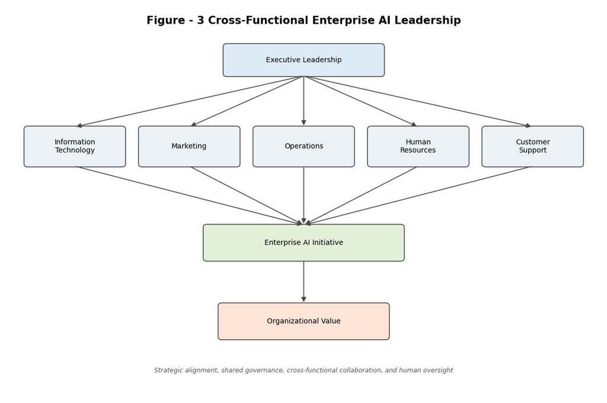

```python
import matplotlib.pyplot as plt
from matplotlib.patches import FancyBboxPatch, FancyArrowPatch

fig, ax = plt.subplots(figsize=(12, 8))
ax.set_xlim(0, 12)
ax.set_ylim(0, 10)
ax.axis("off")

def add_box(x, y, w, h, text, facecolor):
    box = FancyBboxPatch(
        (x, y),
        w,
        h,
        boxstyle="round,pad=0.02,rounding_size=0.08",
        linewidth=1.2,
        edgecolor="#4a4a4a",
        facecolor=facecolor
    )
    ax.add_patch(box)
    ax.text(
        x + w / 2,
        y + h / 2,
        text,
        ha="center",
        va="center",
        fontsize=10
    )

def add_arrow(x1, y1, x2, y2):
    arrow = FancyArrowPatch(
        (x1, y1),
        (x2, y2),
        arrowstyle="-|>",
        mutation_scale=14,
        linewidth=1.2,
        color="#4a4a4a"
    )
    ax.add_patch(arrow)

# Title
ax.text(
    6,
    9.6,
    "Figure - 3 Cross-Functional Enterprise AI Leadership",
    ha="center",
    va="center",
    fontsize=15,
    fontweight="bold"
)

# Executive leadership
add_box(
    4.4, 8.2, 3.2, 0.8,
    "Executive Leadership",
    "#DDEBF7"
)

# Functional areas
departments = [
    ("Information\nTechnology", 0.4),
    ("Marketing", 2.7),
    ("Operations", 5.0),
    ("Human\nResources", 7.3),
    ("Customer\nSupport", 9.6)
]

for label, x in departments:
    add_box(
        x, 5.9, 2.0, 1.0,
        label,
        "#EAF2F8"
    )
    add_arrow(
        6.0, 8.2,
        x + 1.0, 6.9
    )

# Enterprise AI initiative
add_box(
    4.0, 3.5, 4.0, 0.9,
    "Enterprise AI Initiative",
    "#E2F0D9"
)

for _, x in departments:
    add_arrow(
        x + 1.0, 5.9,
        6.0, 4.4
    )

# Organizational value
add_box(
    4.3, 1.5, 3.4, 0.9,
    "Organizational Value",
    "#FCE4D6"
)

add_arrow(
    6.0, 3.5,
    6.0, 2.4
)

ax.text(
    6,
    0.7,
    "Strategic alignment, shared governance, cross-functional collaboration, and human oversight",
    ha="center",
    va="center",
    fontsize=9,
    style="italic",
    color="#555555"
)

plt.tight_layout()
plt.show()
```

### Figure - 4. Workshop 3 Concept Map

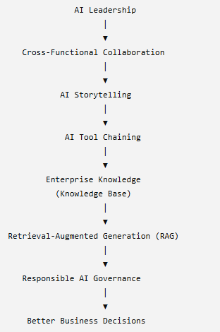

# 5. Summary

Workshop 3 examined the leadership and organizational dimensions of Artificial Intelligence, emphasizing that successful AI initiatives depend on collaboration between technical and non-technical professionals, effective communication, and responsible governance. Students explored how multidisciplinary teams contribute to AI projects, how Generative AI supports storytelling and organizational innovation, and how multiple AI tools can be integrated into coordinated enterprise workflows.

The enterprise case studies demonstrated how organizations can apply Generative AI and RAG to support knowledge management, customer service, decision-making, and operational efficiency while maintaining appropriate privacy, security, and governance practices. Across all activities, the workshop reinforced that Artificial Intelligence is most effective when it augments human expertise rather than replacing it. Responsible leadership, ethical oversight, multidisciplinary collaboration, and continuous evaluation remain essential for creating trustworthy AI systems that generate sustainable organizational value.

# 6. References, Further Reading, and Data Sources

## References

Brown, T. B., Mann, B., Ryder, N., Subbiah, M., Kaplan, J., Dhariwal, P., et al. (2020). *Language models are few-shot learners*. Advances in Neural Information Processing Systems, 33, 1877–1901.

Dellermann, D., Ebel, P., Söllner, M., & Leimeister, J. M. (2019). Hybrid intelligence. *Business & Information Systems Engineering, 61*(5), 637–643.

Edmondson, A. C. (1999). Psychological safety and learning behavior in work teams. *Administrative Science Quarterly, 44*(2), 350–383.

Goodfellow, I., Bengio, Y., & Courville, A. (2016). *Deep Learning*. MIT Press.

Kaplan, A., & Haenlein, M. (2020). Rulers of the world, unite! The challenges and opportunities of Artificial Intelligence. *Business Horizons, 63*(1), 37–50.

Lewis, P., Perez, E., Piktus, A., Petroni, F., Karpukhin, V., Goyal, N., et al. (2020). Retrieval-Augmented Generation for knowledge-intensive NLP tasks. *Advances in Neural Information Processing Systems, 33*, 9459–9474.

Russell, S., & Norvig, P. (2021). *Artificial Intelligence: A Modern Approach* (4th ed.). Pearson.

Salas, E., Reyes, D. L., & McDaniel, S. H. (2018). The science of teamwork: Progress, reflections, and the road ahead. *American Psychologist, 73*(4), 593–600.

Vaswani, A., Shazeer, N., Parmar, N., Uszkoreit, J., Jones, L., Gomez, A. N., et al. (2017). Attention Is All You Need. *Advances in Neural Information Processing Systems, 30*.

## Further Reading

Microsoft. (2024). *Microsoft Annual Report 2024.*

Microsoft. (2024). *Microsoft Form 10-K.*

Microsoft. (2024). *Microsoft Shareholder Letter 2024.*

OpenAI. (2025). *GPT-4.1 Technical Report.*

World Economic Forum. (2025). *AI Governance Alliance Reports.*

McKinsey & Company. (2025). *The State of AI.*

Deloitte. (2024). *State of AI in the Enterprise.*

## Data Sources

The demonstrations presented in this notebook utilize publicly available Microsoft corporate documents included in the Microsoft Enterprise Knowledge Repository. These materials are provided solely for educational purposes to illustrate enterprise knowledge management, document retrieval, Retrieval-Augmented Generation (RAG), and AI-assisted business decision-making.

Primary data sources include:

- Microsoft Annual Report 2024
- Microsoft Form 10-K (2024)
- Microsoft Shareholder Letter (2024)

Additional demonstrations are based on conceptual enterprise scenarios developed for instructional purposes and do not represent proprietary organizational data.

## Software and Technologies

The interactive demonstrations in this notebook utilize the following open-source software and libraries:

- Python 3.x
- Jupyter Notebook
- pandas
- NumPy
- Matplotlib
- python-docx
- pathlib
- IPython

These technologies are used exclusively to illustrate enterprise AI concepts and support the conceptual learning objectives of AIML-505.

### License

MIT License  
Copyright (c) 2026 Dr. Eskinder Belete

**Author**: Dr. Eskinder Belete  
**Copyright**: © 2026 Eskinder B. All rights reserved.